None

# From Lumped-Parameter Dynamic Modeling in ES103 to Lagrangian Mechanics

This notebook is designed to provide a "bridge" from the energy-based, lumped-parameter dynamic modeling tools [you learned in ES103](https://alexanderallenbrown.github.io/ES103_SP23_Students/) to ["Lagrange's Method"](https://scholar.harvard.edu/files/david-morin/files/cmchap6.pdf) for building dynamic models of *mechanical* systems of masses, dampers, springs, and power transucers. Lagrange's method is primarily used for purely mechanical systems, and its use is very common in certain corners of robotics and vehicle dynamics. As we will see, it has a lot of utility when the motion of a complex system is written in certain types of coordinates (polar or path coordinates, for example).

This notebook begins by solving for the equations of motion of a simple mechanical system using the methods from ES103. Then, it solves for the same equations of motion using a slightly quicker, "Lazy" application of the first law... which should seem natural given what you learned in ES103. Then, the notebook does the same for a more complex system before introducing LaGrange's method formally. Finally, the notebook discusses why and how LaGrange's method differs from the techniques you employed in ES103.

## A Spring-Mass-Damper System the ES103 Way

Consider the following spring-mass-damper system, already scoped appropriately to include just three elements:

- a mass $m_1$ that translates with velocity $v_1$ and [stores kinetic energy](https://alexanderallenbrown.github.io/ES103_SP23_Students/ES103_Summary_Resource/ES103_Summary_Resource.html#First-Law-Assumptions-for-Common-System-Elements)
- an idealized translational damper $b_1$ that [dissipates energy](https://alexanderallenbrown.github.io/ES103_SP23_Students/ES103_Summary_Resource/ES103_Summary_Resource.html#First-Law-Assumptions-for-Common-System-Elements).
- an idealized translational spring $K_1$ that [stores potential energy](https://alexanderallenbrown.github.io/ES103_SP23_Students/ES103_Summary_Resource/ES103_Summary_Resource.html#Mechanical-Springs).

In addition, there is an input force from an idealized "infinite-power source" that provides a known force $F_i$ to the system, regardless of how much power that requires (i.e. regardless of how large the velocity $v_1$ might be).

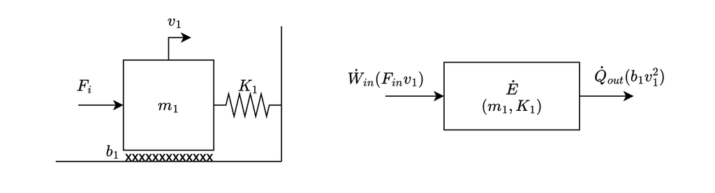

In ES103, you learned how to represent this system as an [equivalent generalized circuit](https://alexanderallenbrown.github.io/ES103_SP23_Students/ES103_Summary_Resource/ES103_Summary_Resource.html#Generalized-Equivalent-Circuits), which for this system, might look like the following.

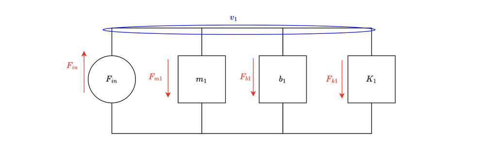

This equivalent circuit has one node and four "branches" including the input. Writing out the element, loop, and node equations for this system yields:

Combining equations (1) - (4) and defining $x_1 = \frac{F_{k1}}{K_1}$ (Hooke's Law) as our dependent variable of interest, or "system output," We get our final model:

\begin{equation} m_1 \ddot{x}_1 + b_1\dot{x}_1 + K_1 x_1 = F_{in} \end{equation}

It is second-order, which makes sense since the system has two independent energy-storing elements, and the units of all terms in the above equation are Newtons, so the system passes our checks for internal validity.

## A Spring-Mass-Damper System Model the "Energetic Lazy Way."

What if I told you that at least for *this* system, there was a way to use the First Law to get a model for our spring-mass-damper system in *two easy steps?* Well, there is... but there's a catch. This method **does not work for all types systems (including mixed systems) and/or all coordinate definitions** (but neither does the equivalent-circuit method from ES103 work for *all* systems and coordinate definitions). Anyway, let's try it out to see how it works. The disciplined process for this method is:

1. Write the time-derivative of the First Law for the *total energy* in our system (i.e. the First Law in "power form") using your overall energetic diagram for the system.
2. Cancel any "extra" variables

This should look suspiciously like the method we learned in ES103 for building models of simple systems before introducing equivalent circuits. For the spring-mass-damper system, The total energy **inside the system boundary** can be written as the sum of the energy in the Spring, or $E_{K1}=\frac{1}{2K_1}F_{k1}^2 = \frac{1}{2}K_1x_1^2$, and the energy in the mass, or $E_{m1}=\frac{1}{2}m_1 v_1^2$. This means that our First Law's time derivative, according to our energetic diagram above, is:

\begin{equation} \dot{E}_{sys} = \dot{E}_{k1}+\dot{E}_{m1} = \dot{W}_{in}-\dot{Q}_{out} \end{equation}

Substituting in what we know, including that we want the mass's position $x_1$ to be our dependent variable rather than its derivative $v_1 = \dot{x}_1$, we get:

\begin{equation} m_1\ddot{x}_1\dot{x}_1 + K_1x_1\dot{x}_1 = F_{in}\dot{x}_1 - b_1 \dot{x}_1^2 \end{equation}

Noting that all terms are multiplied by our mass's velocity $v_1=\dot{x}_1$, we can cancel one power of $\dot{x}_1$ from the equation, which yields the same equation of motion that we got using the "full process" from ES103 (equation 5). Seems easy!

### What does it mean to "cancel the extra power variable" in this equation?

Around the mid-point of ES103, we used this same process on the element-level to develop our "elemental first law" equations. Part of that process was "canceling the extra power variable" in our final equation. One thing that ES103 doesn't point out (but could) is that what we're doing in that step is equivalent to taking a "partial derivative" of the first law with respect to one of our system's power variables. What we're actually doing to get our final model can be written as:

\begin{equation} \frac{\partial}{\partial \dot{x_1}}\left( \frac{d}{dt} E_{sys} \right)= \frac{\partial}{\partial \dot{x_1}}\left( \frac{d}{dt}\left( W_{in} - Q_{out} \right) \right)\end{equation}

Note that this **only works** if the heat dissipated by damping/friction/loss terms is written in the form $F_d\dot{q}_i$. If you substitute in an elemental equation, for example $F_d = b_i\dot{q}_i$, then the equation for $\dot{Q}_{out}=b_i\dot{q}^2_i$, and taking the partial derivative will result in an "extra" factor of 2.

This realization is not very useful right now, but it will be as we begin to look at system dynamics using LaGrange's method.

## Applying these methods to a more complex system

Let's see what happens with a more complex system if we write out the derivative of the first law for the *entire* system. We'll use a similar system to the one in the previous section, but we'll connect another mass $m_2$ to our spring (rather than connecting it to ground) and let the friction between mass and ground be represented by an idealized damper $b_2$. Looking at the system after we "scope" it, we get the following equivalent circuit representation and overall energetic diagram.

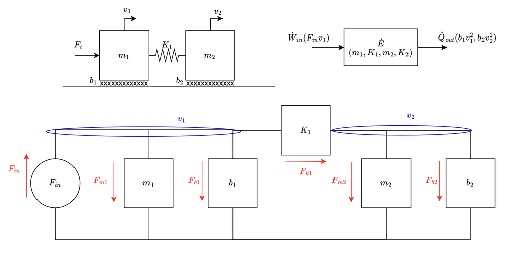

### Exercise: Build a model for this system the ES103 way

To help you brush up on your ES103 skills, confirm that the model above will produce the following equations of motion in state space form. **Use the full ES103 equivalent circuit process.** Use velocities $v_1$ (representing how mass $m_1$ stores energy) and $v_2$ (representing how mass $m_2$ stores energy) along with force $F_{k1}$ (representing how spring $K_1$ stores energy) as our three "energetically independent" states.

\begin{equation} \begin{aligned} \frac{d}{dt}{F_{k1}} &= K_1\left(v_1-v_2\right) \\ \frac{d}{dt}{v}_1 &= \frac{1}{m_1} \left(F_{in}-b_1v_1-F_{k1}\right)\\ \frac{d}{dt}{v}_2 &= \frac{1}{m_2} \left(F_{k1}-b_2v_2\right) \end{aligned} \end{equation}

### Re-defining our set of state variables $\vec{x}$

You may or may not remember from ES103 that the states you chose for your equations of motion aren't *unique* but that the *minimum* number of states needed to describe a system is equal to the number of *independent* energy storage processes in your system's scope. You can always choose to define more states, whether they're "necessary" or not. Control systems engineers do this all the time to help design algorithms that regulate a system in creative ways, for example.

To help us with the transition to LaGrangian mechanics, we will modify our model's states to represent *positions* of each mass. In LaGrange's method, we count a mechanical system's **degrees of freedom** rather than counting the number of energy storage processes as we scope our model. Those two terms are close, but a **degree of freedom** is an independent direction in which our system can move. This could be a rotational angle, or a translational position, or sometimes even a combination (like a system that's constrained to move along a curved path). Our system has two "degrees of freedom" because the positions of our two masses, which we could call $x_1$ and $x_2$, must be described *indpendently* since our two masses are energetically independent and can move in ways that aren't geometrically linked to one another.

So let's change our model's states to reflect a model that describes the position of each mass. If we write our model out by simply transforming velocities into the derivatives of position, we get:

\begin{equation} \begin{aligned} \frac{d}{dt}F_{k1} &= K_1\left(\dot{x}_1-\dot{x}_2\right) \\ \frac{d}{dt}\dot{x}_1 &= \frac{1}{m_1} \left(F_{in}-b_1\dot{x}_1-F_{k1}\right)\\ \frac{d}{dt}\dot{x}_2 &= \frac{1}{m_2} \left(F_{k1}-b_2\dot{x}_2\right) \end{aligned} \end{equation}

This is the same model, but I'd like to go a bit further. We still have one of our state variables that isn't a position... $F_{k1}$. We can always express $F_{k1}$ using Hooke's law: $F_{k1}=K_1\left(x_1-x_2\right)$. This leads to the following modified form of the model above:

\begin{equation} \begin{aligned} \frac{d}{dt}{F_{k1}} &= K_1\left(\dot{x}_1-\dot{x}_2\right) \\ \frac{d}{dt}\dot{x}_1 &= \frac{1}{m_1} \left(F_{in}-b_1\dot{x}_1-K_1(x_1-x_2)\right)\\ \frac{d}{dt}\dot{x}_2 &= \frac{1}{m_2} \left(K_1(x_1-x_2)-b_2\dot{x}_2\right) \end{aligned} \end{equation}

Note that this isn't quite in state space form any more. We could, if we wanted, decide to remove $F_{k1}$ from our list of state variables, since the other two equations no longer contain $F_{k1}$. However, this would require us to add $x_1$ AND $x_2$, to our list of state variables, since each state derivative equation [must only be a function of our states and inputs](https://alexanderallenbrown.github.io/ES103_SP23_Students/ES103_Summary_Resource/ES103_Summary_Resource.html#Differential-Equation-Models-in-%22State-Space%22-Form). This makes our model 4th order, which is fine, because the *minimum* number of states we need is 3. Our final model in state space form is then:

\begin{equation} \begin{aligned} \frac{d}{dt} x_1 &=\dot{x_1}\\ \frac{d}{dt} x_2 &=\dot{x_2}\\ \frac{d}{dt}\dot{x}_1 &= \frac{1}{m_1} \left(F_{in}-b_1\dot{x}_1-K_1(x_1-x_2)\right)\\ \frac{d}{dt}\dot{x}_2 &= \frac{1}{m_2} \left(K_1(x_1-x_2)-b_2\dot{x}_2\right) \end{aligned} \end{equation}

### Can we reproduce this model using the "Energetic Lazy Way?"

Now, let's apply the disciplined process we learned above to see what we can come up with by writing the time-derivative of the first law for the *entire* system. We will write everything in terms of $x_1$,$x_2$, and their derivatives so that we can reproduce the model in Equation 12, which was obtained using only methods you learned in ES103.

Using the energetic diagram for the system, we can write:

\begin{equation} \dot{E}_{sys} = \dot{E}_{k1}+\dot{E}_{m1}+\dot{E}_{m2} = \dot{W}_{in}-\dot{Q}_{out} \end{equation}

Substituting each term with what we know about our energy storage and dissipation processes, we obtain:

\begin{equation} m_1 \dot{x_1}\ddot{x}_1 + m_2 \dot{x_2}\ddot{x}_2 + K_1\left(x_1-x_2\right)\left(\dot{x}_1-\dot{x}_2\right) = F_{in}\dot{x}_1 - F_{b1}\dot{x}_1 - F_{b2}\dot{x}_{2} \end{equation}

Now, in our first example, we were able to simply "cancel out" the extra factor of $\dot{x}_1$ to obtain our final model. Here, that's simply not possible, because not every term is multiplied by $\dot{x}_1$! However, recall Equation 8, which was an "equivalent" statement for the first example.

$$\frac{\partial}{\partial \dot{x_1}}\left( \frac{d}{dt} E_{sys} \right)= \frac{\partial}{\partial \dot{x_1}}\left( \frac{d}{dt}\left( W_{in} - Q_{out} \right) \right)$$

if we apply Equation 8 to Equation 14, all terms not multiplied by $\dot{x}_1$ go to zero, and we get (after some minor rearranging):

\begin{equation} \ddot{x}_1 = \frac{1}{m_1} \left(F_{in}-b_1\dot{x}_1-K_1(x_1-x_2)\right)\\ \end{equation}

This is the *SAME EQUATION* as one of our state derivative equations in Equation 12! But the problem is that this is not a **total picture** of how the energy in our system changes over time because it only looks at changes with respect to power flow in the $x_1$ "degree of freedom." So, what we can do is Apply Equation 8 again, but instead of taking the partial derivative of our FLT's time derivative with respect to $\dot{x}_1$, we take the partial derivative with respect to $\dot{x}_2$ instead:

$$\frac{\partial}{\partial \dot{x_2}}\left( \frac{d}{dt} E_{sys} \right)= \frac{\partial}{\partial \dot{x_2}}\left( \frac{d}{dt}\left( W_{in} - Q_{out} \right) \right)$$

Doing this leads to the following (again, after some minor rearranging):

\begin{equation} \ddot{x}_2 = \frac{1}{m_2} \left(K_1(x_1-x_2)-b_2\dot{x}_2\right) \end{equation}

Equation 16, Equation 15, and the simple definitions of $\frac{d}{dt}x_1=\dot{x}_1$ and $\frac{d}{dt}x_2=\dot{x}_2$ make up the same state space equations that we got for this system using the equivalent circuit methods of ES103.

### Updated "Energetic Lazy Way" Disciplined process

What we did here could, in theory, be generalized to a system with any number of mechanical "degrees of freedom" (displacements or positions whose velocities represent energetically independent motion of a mechanical system). What our updated process would look like is something like this if we assume that our mechanical system has $n$ "positional degrees of freedom" $\vec{q} = \begin{bmatrix}q_1 & q_2 & \ldots & q_n\end{bmatrix}$:

1. Write the time-derivative of the First Law for the *total energy* in our system (i.e. the First Law in "power form") using your overall energetic diagram for the system.
2. For each energetically independent positional degree of freedom in the system $q_i$, compute $\frac{\partial}{\partial \dot{q_i}}\left( \frac{d}{dt} E_{sys} \right)= \frac{\partial}{\partial \dot{q_i}}\left( \frac{d}{dt}\left( W_{in} - Q_{out} \right) \right)$

What we've done here is we have **almost** re-discovered LaGrange's method for determining the equations of motion of a dynamic mechanical system. However, our method is more limited, because we need to make sure that our degrees of freedom $\vec{q}$ allow us to write our Kinetic energy as a function of velocities *only* and our potential energy as a function of positions *only*.

## LaGrange's Method

LaGrange's method for obtaining the equations of motion for a dynamic mechanical system is well-summarized [here](https://scholar.harvard.edu/files/david-morin/files/cmchap6.pdf) and its development in that resource is supported by its traditional theoretical underpinnings. If you're just recently coming out of ES103, it may be difficult to relate to the way that LaGrange's method, Hamilton's Principle, and Newton's Laws are all related. However, you **are** familiar with the conservation of energy, and in a way, Hamilton's Principle states that the first law and Newton's Laws are consistent with one another.

Lagrange's method uses something a bit like $E_{sys}$, or the system's total energy, in its formulation. The "Lagrangian," often denoted $L$, is the *difference* between a system's kinetic energy (called $T$) and its potential energy (called $V$). In other words,

\begin{equation} L \equiv T-V \end{equation}

Lagrange's method for determining a system's equations of motion uses the LaGrangian $L$. It states that for a system with $n$ **arbitrary degrees of freedom or 'generalized coordinates'** $\vec{q} = \begin{bmatrix}q_1 & q_2 & \ldots & q_n\end{bmatrix}$, which can either be rotations or translations, its equations of motion can be obtained by computing for each degree of freedom $q_i$:

\begin{equation} \frac{d}{dt}\left(\frac{\partial L}{\partial \dot{q}_i}\right)- \frac{\partial L}{\partial q_i} = \tau_i \end{equation}

This process of applying Equation 18 produces what are commonly called the "Euler-LaGrange Equations" for a system (these are its equations of motion, not quite in state space form, but easily transformed).

In Equation 18, $\tau_i$ represents the net "non-conservative" force (if $q_i$ is a translational coordinate) or torque (if $q_i$ is a rotational coordinate) acting on the system. Non-conservative means that the force (or torque) causes energy to cross the system boundary, which makes sense, since the left half of the equation only deals with $L$, which is just a statement about the system's *internal* potential and kinetic energy. This should already look a bit like our "Energetic Lazy" disciplined process summarized in Section 3.4. However, there are some differences, so let's take a moment to look more closely at where the similarities begin and end.

## Comparing the Euler-LaGrange Equations with the "Energetic Lazy Way."

If we expand Equation 18 to explicitly account for both kinetic energy "$T$" and potential energy "$V$" contained in the system. We recognize that the sum of the "non-conservative" torques $\tau_i$ in each degree of freedom $i$ can also be written (for most systems we studied in ES103 anyway) as $\frac{\partial}{\partial \dot{q}_i} \left(\frac{d}{dt} \left( W_{in}-Q_{out} \right) \right)$. Noting these two things, Equation 18 can be written in a way that starts to look more like the results of the disciplined process in Section 3.4:

\begin{equation} \frac{d}{dt}\left(\frac{\partial T }{\partial \dot{q}_i}\right)- \frac{d}{dt}\left(\frac{\partial V}{\partial \dot{q}_i} \right)- \frac{\partial T}{\partial q_i} + \frac{\partial V}{\partial q_i} = \tau_i \end{equation}

This has some similarities to what we got for the "Energetic Lazy" disciplined process.

- The units of each term have the units of torque if $q_i$ is a rotational coordinate, and force if $q_i$ is a translational coordinate.
- The first two terms contain both a time derivative and a partial derivative with respect to a power variable (a velocity or rotational velocity).

But as you can see, there are also some important differences between Equation 19 and the method of Section 3.4.

- The time-derivative of the system's internal energy terms (kinetic and potential) is taken *after* taking their partial derivatives with respect to the power variable, rather than before.
- There is a term corresponding to the partial derivative of each internal energy term with respect to each *positional* degree of freedom (not a power variable).

This is because LaGrange's method was derived in a different way than the method of section 3.4. If both are "valid," they should *always* give the same results. They **do not**, and LaGrange's method generalizes to more mechanical system definitions than the method of Section 3.4. We will explore that in a bit, but first, let's explore how the methods perform on the 3rd order system example we introduced in Section 3.

For our 3rd order system (which we'll continue to call 3rd order even though we wrote a 4th order set of state space equations for it), kinetic energy $T$ is:

\begin{equation} T=\frac{1}{2}\left(m_1\dot{x}_1^2 + m_2 \dot{x}_2^2\right) \end{equation} and Potential Energy $V$ is: \begin{equation} V=\frac{1}{2}K_1\left(x_1-x_2\right)^2 = \frac{1}{2}K_1\left(x_1^2-2x_1x_2+ x_2^2\right) \end{equation}

adding those terms together, and adding in the non-conservative force $\tau_{x1}=-b_1\dot{x}_1+F_{in}$ on the right-hand side of Equation 19 does in fact give us the correct equation of motion! **As an exercise, try to reproduce Equation 16 using LaGrange's method as well.**

While this document will **not** go into *why* this is the case, suffice it to say that the method of Section 3.4 is missing something important for systems whose DOF are defined in a way that requires kinetic energy to be a function of both generalized (rotational or translational) *positions* and *velocities*, or in a way that requires potential energy to be written as a function of both generalized *positions* and *velocities*.

If all of a system's DOF are cartesian translational or rotational coordinates defined with respect to a Newtonian (non-moving) reference frame, for example, LaGrange's method and the "Lazy Energetic" method should produce the same equations of motion. However, if this is not the case, you *must* use LaGrange's method (or a carefully executed version of Newton's 2nd law) to obtain the system's equations of motion.

Here is an illustrative example.

## When Being "Lazy" with Energy Fails Us (and so do the modeling tools in ES103)

Consider the following system that consists of a small marble that has mass $m$ and rides in a slot cut out of a disk. The disk rotates in the horizontal plane. The marble experiences approximate viscous damping $b$ between it and the slot due to a greased contact with the slot's walls, and there is a spring holding the marble at the center of the disk when the disk is not rotating.

Our model scope is concerned with the motion of the marble and the spring-- the disk is essentially massless compared with the marble, so we can ignore any contribution it has to the system's internal energy. What we're interested in is how the marble's position $\rho$ away from the disk's center (our dependent variable) evolves over time if the disk is given some initial spin rate $\dot{\theta}$, and how $\dot{\theta}$ itself will change as the marble moves. This means our system has two "degrees of freedom:" $\vec{q}=\begin{bmatrix}\rho & \theta \end{bmatrix}$. One is translational (the marble's motion) and the other is rotational. This means that when we get our equations of motion, we'd expect one of them to contain terms that have units of force (the $\rho$ eqn) and the other to contain terms that have units of torque (the $\theta$ eqn).

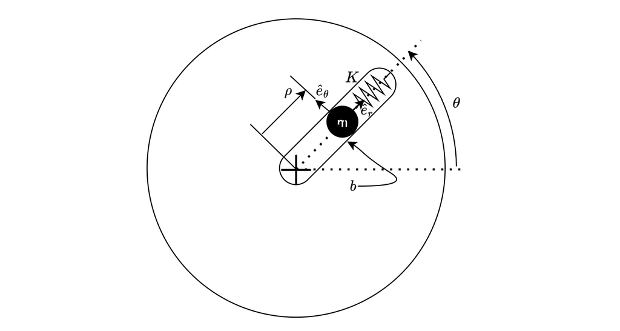

To apply either the "Lazy Energetic" disciplined process from Section 3.4 *or* LaGrange's method, we need to express the kinetic and potential energy contained within our system. I will leave a verification of the following to you via a formal model scoping process, but let's proceed for now with the presumption that the system's internal kinetic energy is only due to the marble's motion, and that its potential energy is only due to the spring's compression.

If we use [*polar coordinates*](https://en.wikipedia.org/wiki/Polar_coordinate_system#:~:text=In%20mathematics%2C%20the%20polar%20coordinate,angle%20from%20a%20reference%20direction.) to express the marble's position vector $\vec{\rho}$, whose magnitude $\rho$ is also the spring's compression, we can write $\vec{\rho} = \rho \hat{e}_r$.

Then, we can write the following expression for the marble's velocity:

\begin{equation}\frac{d}{dt}\vec{\rho} = \frac{d\rho}{dt}\hat{e}_r + \rho \frac{d\hat{e}_r}{dt} = \frac{d\rho}{dt}\hat{e}_r + \rho \frac{d\theta}{dt} \hat{e}_{\theta} \end{equation}

If you're not familiar with polar coordinates and their unit vectors, it may be because you didn't use them in Physics (PHYS 131), or you haven't taken Engineering Dynamics (ME240) yet. That's OK! You'll just have to believe me for now that this is how the marble's velocity is written in this *rotating* coordinate system. This means that the *magnitude* of the marble's velocity vector is given by

\begin{equation} \left|\vec{\rho}\right| = \sqrt{\dot{\rho}^2 + \rho^2 \dot{\theta}^2} \end{equation}

This means that the system's Kinetic Energy $T$ can be calculated as:

\begin{equation} T = \frac{1}{2}m\left(\dot{\rho}^2+\rho^2\dot{\theta}^2\right) \end{equation}

The system's potential energy $V$ is due only to the spring's compression and is given by:

\begin{equation} V = \frac{1}{2}K\rho^2 \end{equation}

### What does the "Lazy Energetic" method say (incorrectly) about the system model?

To see how the system model might shake out, we need to compute $\frac{\partial}{\partial \dot{q_i}}\left( \frac{d}{dt} E_{sys} \right)= \frac{\partial}{\partial \dot{q_i}}\left( \frac{d}{dt}\left( W_{in} - Q_{out} \right) \right)$ for each of our degrees of freedom $\vec{q}=\begin{bmatrix}\rho & \theta \end{bmatrix}$.

For our model, doing this requires taking the time derivative of $E_{sys} = T+V = W_{in}-Q_{out}$, which yields:

\begin{equation} \dot{E}_{sys} = m\left(\ddot{\rho}\dot{\rho} + \rho^2\ddot{\theta}\dot{\theta} + \rho\dot{\rho}\dot{\theta}^2\right) + K\rho\dot{\rho} = -F_b\dot{\rho} \end{equation}

Taking the partial derivative of the FLT's time derivative with respect to the marble's motion in the slot, $\dot{\rho}$, yields the model for the $\dot{\rho}$-direction: \begin{equation} m\left(\ddot{\rho}+\rho\dot{\theta}^2\right) + K\rho = -b\dot{\rho} \end{equation} Repeating the same for the $\theta$-direction: \begin{equation} m\ddot{\theta} = 0 \end{equation}

To check this for internal validity, we could look at units and signs, but we really would have to "trust" that our "Lazy Energetic" methodology works. **It does not work here, and in general, you should not use it at all, because it's difficult to know when it will work and when it will not. You should use LaGrange's method instead when building a dynamic model for a complex system that isn't easily modeled using an equivalent circuit**.

We explored the "Lazy Energetic" method in this notebook not to give you another tool in your toolbox, but simply to illustrate how a system's total energy might be used to get a system model "all at once," the way LaGrange's method does. Developing this model using Newton's Laws ($F=ma$) would tell us that our $\rho$-direction equation has a sign mistake in it, and we will confirm this by looking at what LaGrange's method comes up with... which is indeed the correct model.

### What Does LaGrange's method say about the system model?

Computing the derivatives required for the Euler-LaGrange equation of motion for our system's $\rho$ DOF yields the following:

\begin{equation} \begin{aligned} \frac{d}{dt}\left(\frac{\partial T}{\partial \dot{x}_1}\right)&= m\ddot{\rho} \\ -\frac{d}{dt}\left(\frac{\partial V}{\partial \dot{x}_1}\right)&= 0 \\ -\frac{\partial T}{\partial x_1 } &= -m\rho\dot{\theta}^2 \\ \frac{\partial V}{\partial x_1 } &= K\rho \end{aligned} \end{equation}

This yields the following equation of motion for the system in the $\rho$ DOF:

\begin{equation} m\left(\ddot{\rho} - \rho\dot{\theta}^2\right) +K\rho = -b\dot{\rho} \end{equation}